# Assignment4

Sonam Rathod

2024-10-03

```r
# Load necessary libraries
library(forecast)
library(tidyverse)
```

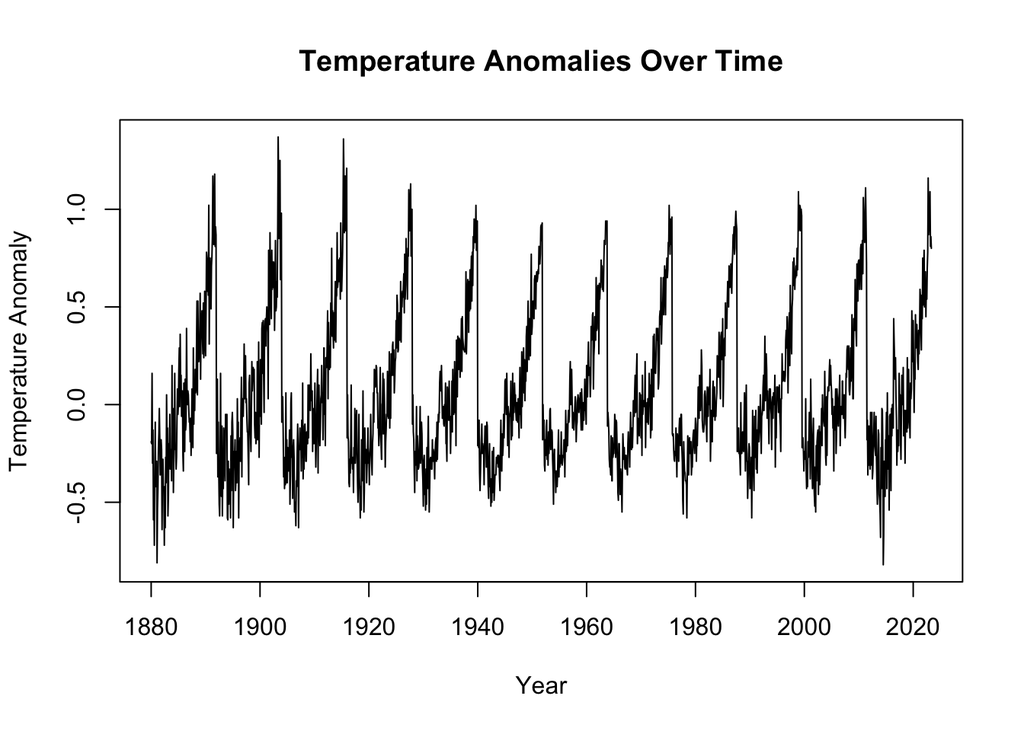

```r
library(lubridate)

global_temps <- read.csv("~/Downloads/archive/global_temps.csv")

global_temps_ts <- global_temps %>%
  gather(key = "Month", value = "Temperature", Jan:Dec) %>%
  mutate(Year = as.Date(paste(Year, match(Month, month.abb), "1", sep = "-"))) %>%
  select(Year, Temperature)
global_temps_ts <- na.omit(global_temps_ts)

# Create the time series object
temperature_ts <- ts(global_temps_ts$Temperature, start = 1880, end = c(2023,5) ,frequency = 12)

# Plot the time series
plot(temperature_ts, main = "Temperature Anomalies Over Time", ylab = "Temperature Anomaly", xlab = "Year")
```

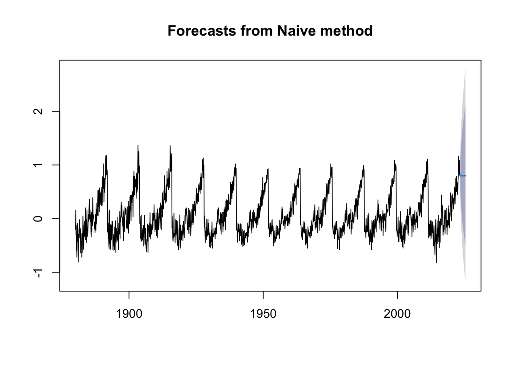

```r
# Naive Forecast
naive_forecast <- naive(temperature_ts, h = 24)
plot(naive_forecast)
```

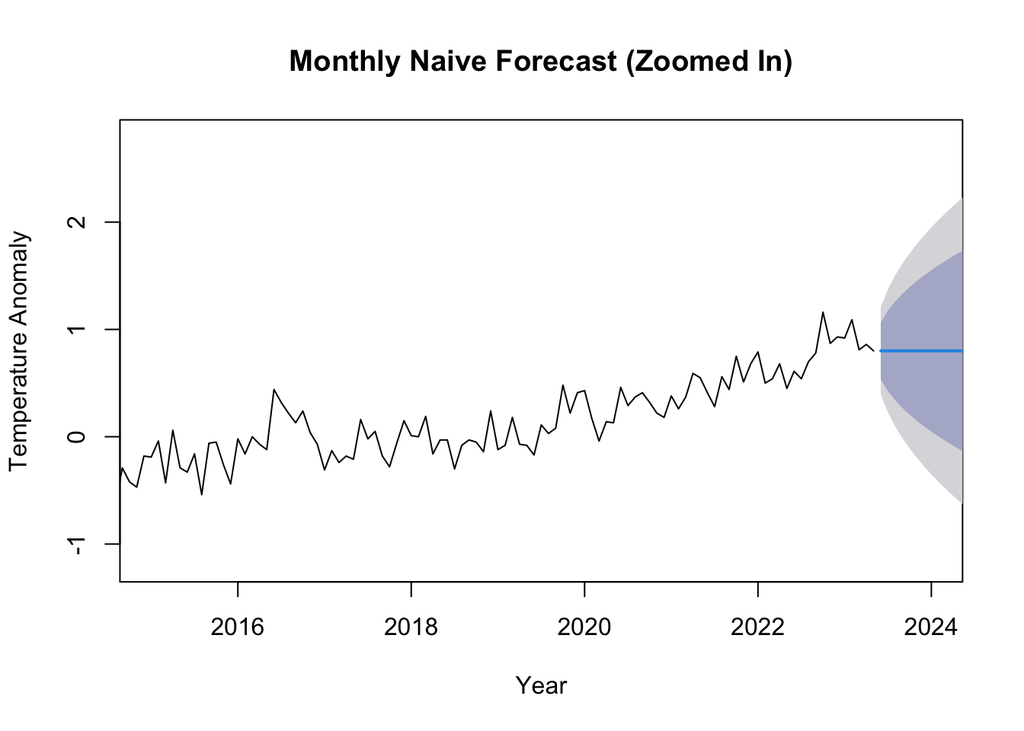

```r
plot(naive_forecast, main = "Monthly Naive Forecast (Zoomed In)", ylab = "Temperature Anomaly", xlab = "Year", xlim = c(2015, 2024))
```

#### The plot displays a flat blue line. This line is the Naive forecast, which assumes that the temperature anomaly will remain constant for the next 24 months. The shaded area around the forecast line represents the 95% prediction intervals.

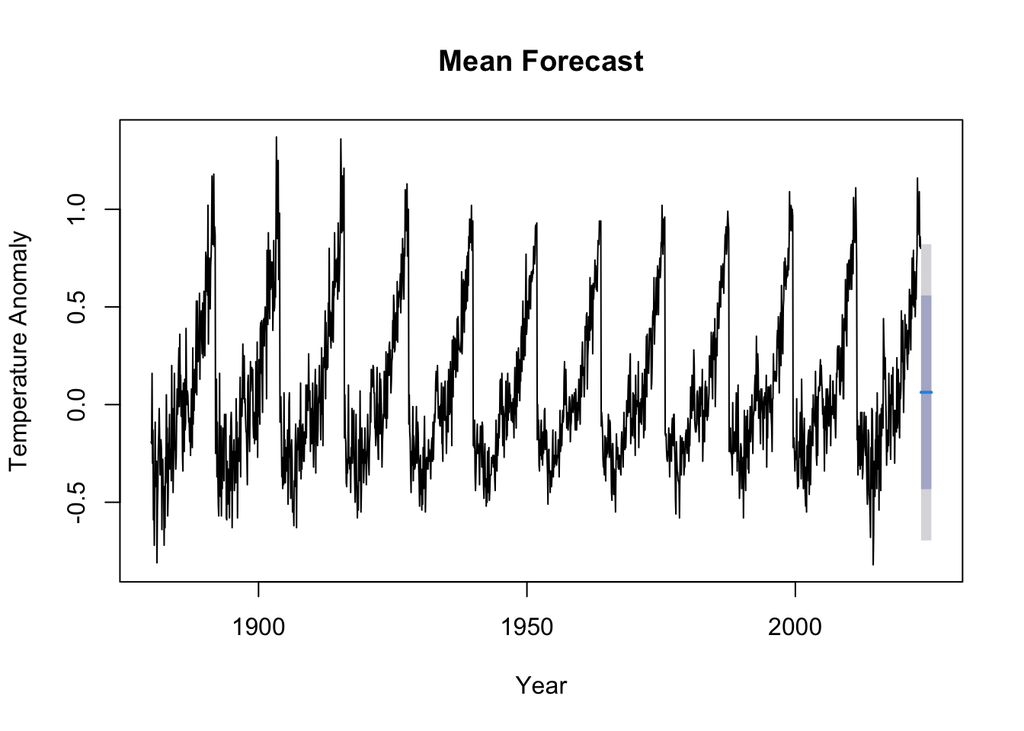

```r
# Applying the Mean Forecast
mean_forecast <- meanf(temperature_ts, h = 24)

# Plot the Mean Forecast
plot(mean_forecast, main = "Mean Forecast", ylab = "Temperature Anomaly", xlab = "Year")
```

#### The forecast is made based on the average of temperature anomalies. The flat blue line represents the future values which is same as the average of all past observations,

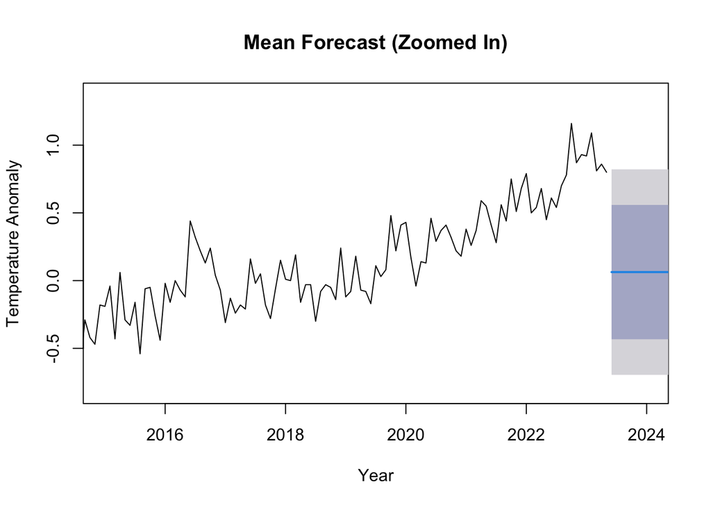

```r
plot(mean_forecast, main = "Mean Forecast (Zoomed In)", ylab = "Temperature Anomaly", xlab = "Year", xlim = c(2015, 2024))
```

#### It shows the flat line for future even if there is a trend or seasonality.

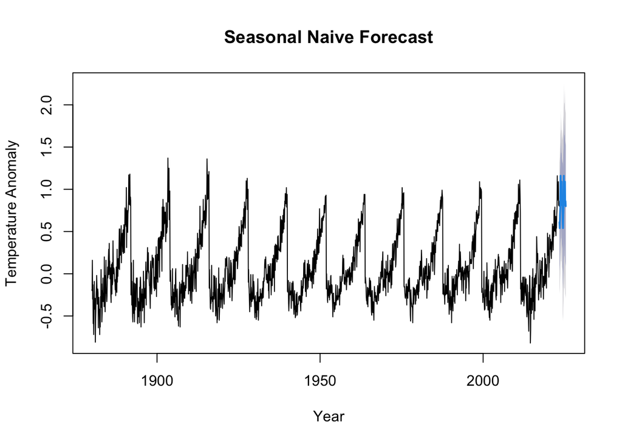

```r
# Applying the Seasonal Naive forecast
snaive_forecast <- snaive(temperature_ts, h =24)

# Plot the Seasonal Naive forecast
plot(snaive_forecast, main = "Seasonal Naive Forecast", ylab = "Temperature Anomaly", xlab = "Year")
```

#### The snaive forecast uses the last observed seasonal pattern to predict future values. The forecasted line matches the seasonal ups and downs of the temperature anomalies from the previous year.

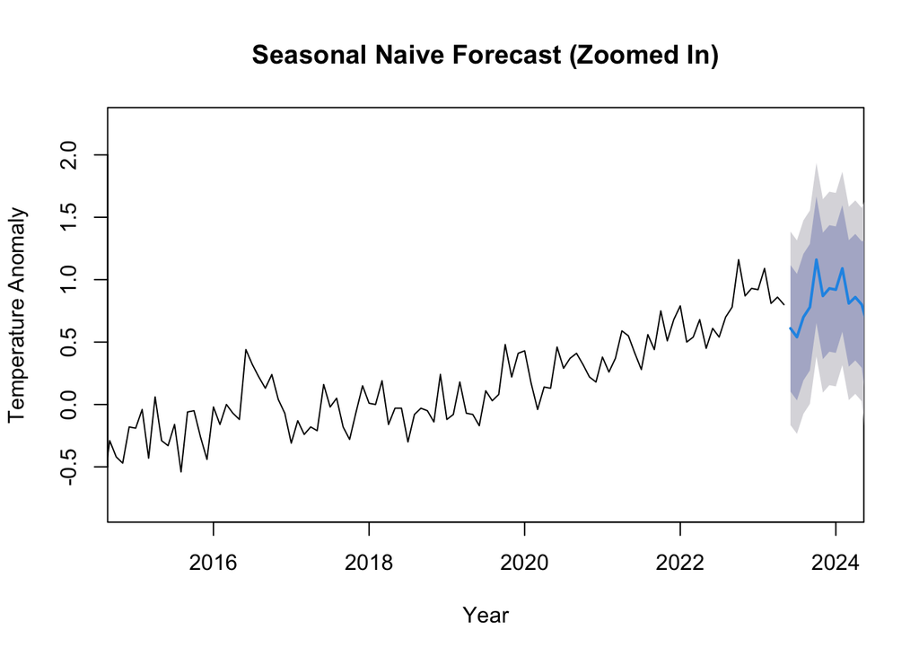

```r
plot(snaive_forecast, main = "Seasonal Naive Forecast (Zoomed In)", ylab = "Temperature Anomaly", xlab = "Year", xlim = c(2015, 2024))
```

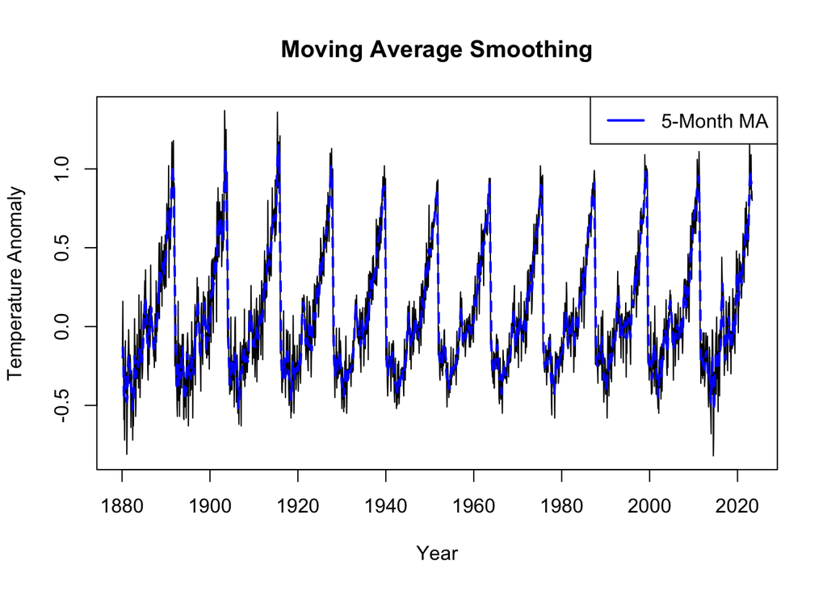

```r
# Apply Moving Average with a window of 5
MA5_forecast <- ma(temperature_ts, order = 5)

# Plot the original time series
plot(temperature_ts, main = "Moving Average Smoothing", ylab = "Temperature Anomaly", xlab = "Year", col = "black")

lines(MA5_forecast, col = "blue", lwd = 2, lty = 2)

# Add a legend to differentiate the series
legend("topright", legend = c( "5-Month MA"),
    col = c( "blue"), lty = 1:2, lwd = 2)
```

#### The blue line represents the 5-month Moving Average (MA), which smooths the time series by calculating the average of temperature anomalies. This smoothing process helps to reduce noise in the data, making it easier to identify the trends and patterns.

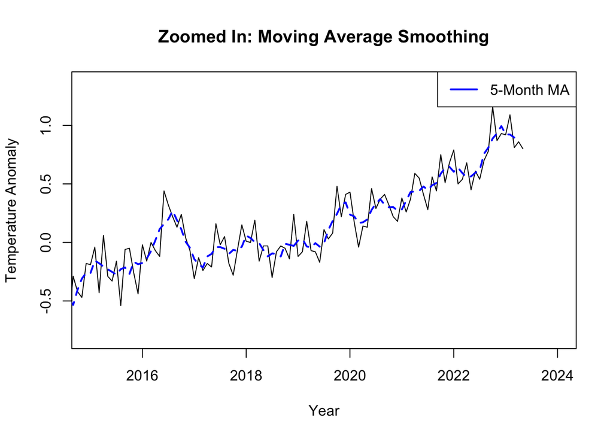

```r
plot(temperature_ts, main = "Zoomed In: Moving Average Smoothing", ylab = "Temperature Anomaly", xlab = "Year",
     xlim = c(2015, 2024), col = "black")
lines(MA5_forecast, col = "blue", lwd = 2, lty = 2)

# Add a legend to differentiate the series
legend("topright", legend = c( "5-Month MA"),
    col = c( "blue"), lty = 1:2, lwd = 2)
```

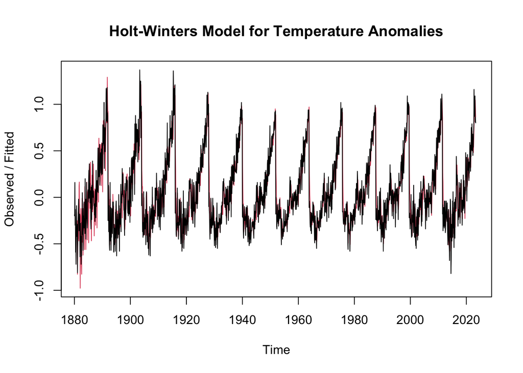

```r
# Apply Holt-Winters model
HW_forecast <- HoltWinters(temperature_ts)

plot(HW_forecast, main = "Holt-Winters Model for Temperature Anomalies")
```

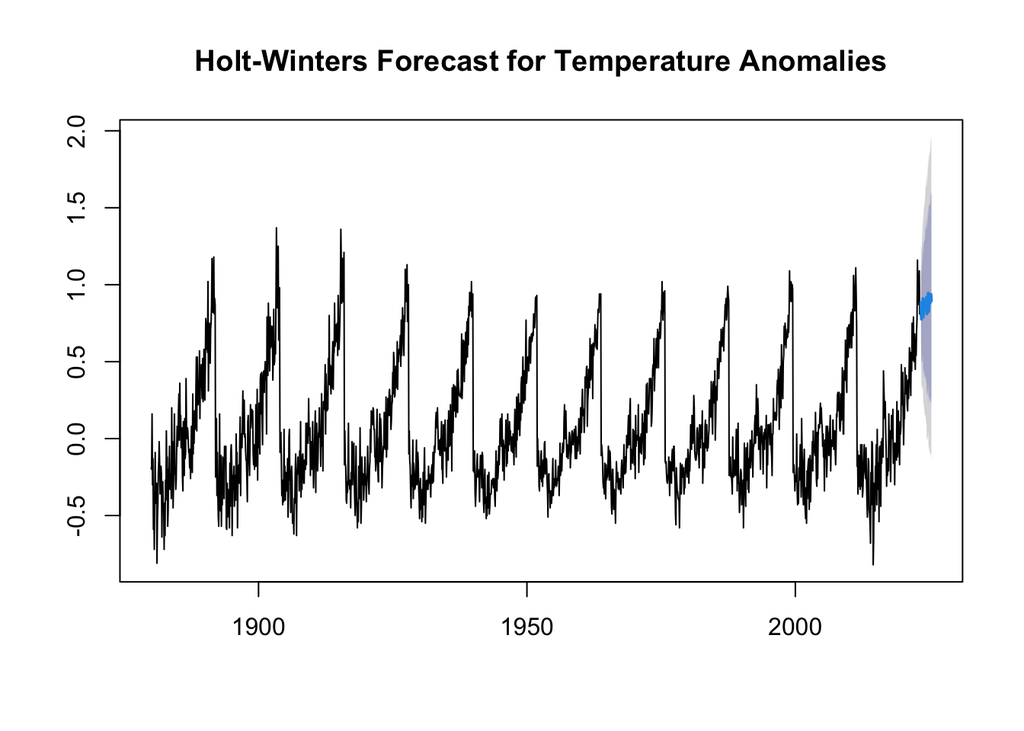

```r
HW_forecast_future <- forecast(HW_forecast, h = 24)

plot(HW_forecast_future, main = "Holt-Winters Forecast for Temperature Anomalies")
```

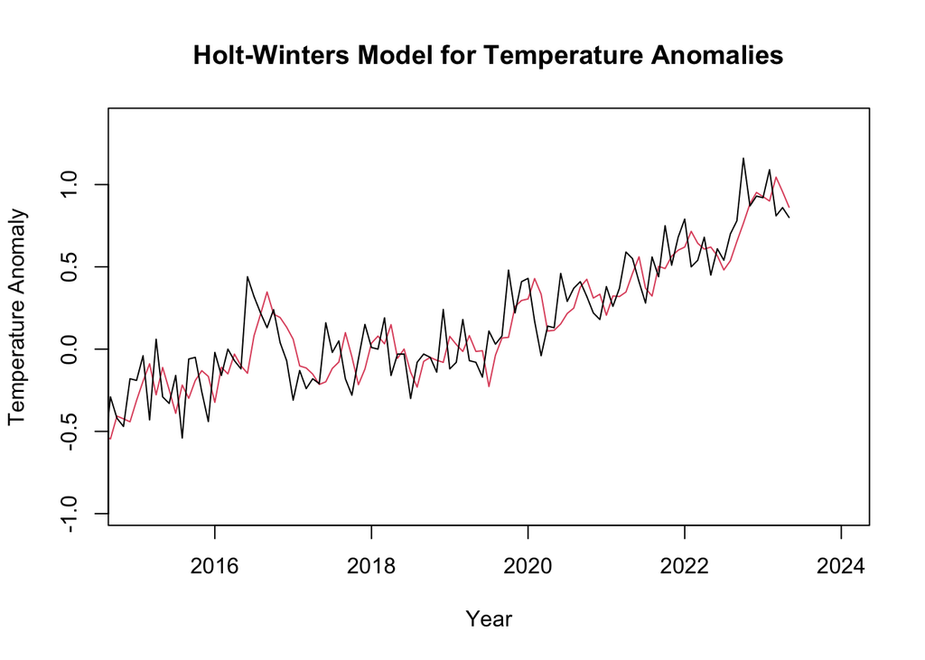

```r
plot(HW_forecast, main = "Holt-Winters Model for Temperature Anomalies",
     ylab = "Temperature Anomaly", xlab = "Year", xlim = c(2015, 2024))
```

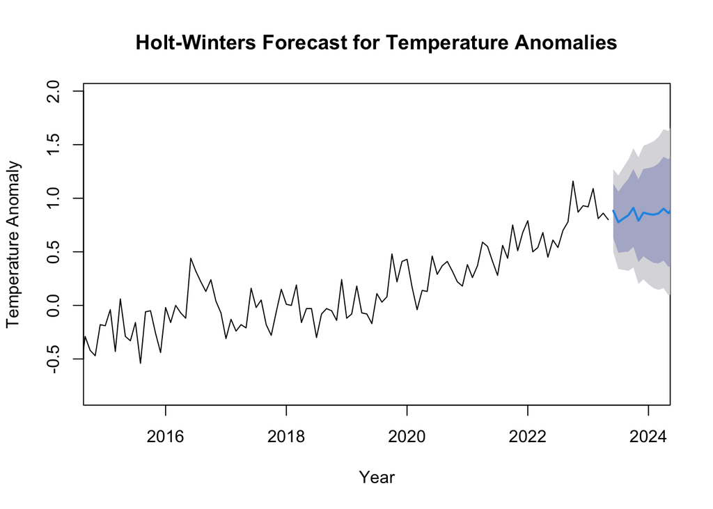

```r
# Forecast for the next 12 months
HW_forecast_future <- forecast(HW_forecast, h = 24)

plot(HW_forecast_future, main = "Holt-Winters Forecast for Temperature Anomalies",
     ylab = "Temperature Anomaly", xlab = "Year", xlim = c(2015, 2024))
```

```r
HW_forecast$alpha
```

```
##     alpha
## 0.5141719
```

```r
HW_forecast$beta
```

```
##         beta
## 0.0003840882
```

```r
HW_forecast$gamma
```

```
##     gamma
## 0.1698304
```

- Alpha (0.514): Moderately balances recent and historical data to update the level.
- Beta (0.00038): Very low, indicating a nearly constant trend over time.
- Gamma (0.169): Slowly adjusts to seasonal changes

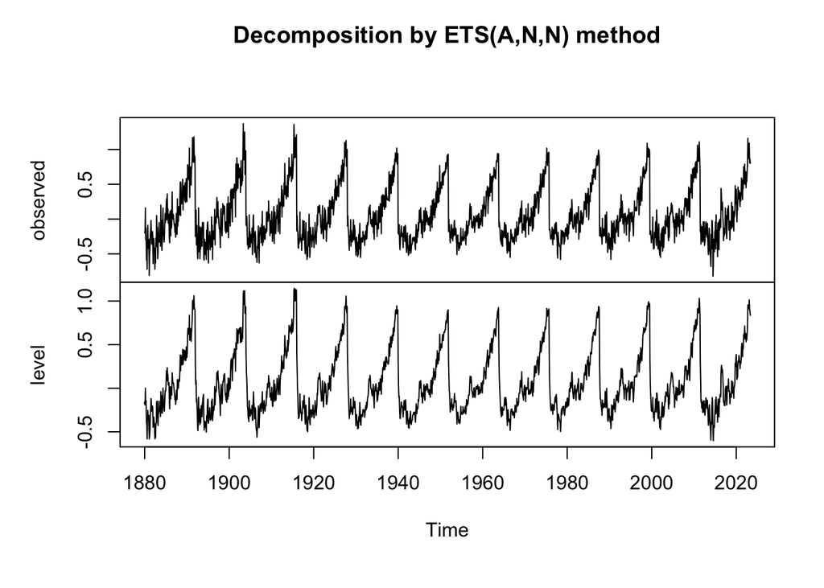

```r
ets_model <- ets(temperature_ts)
plot(ets_model)
```

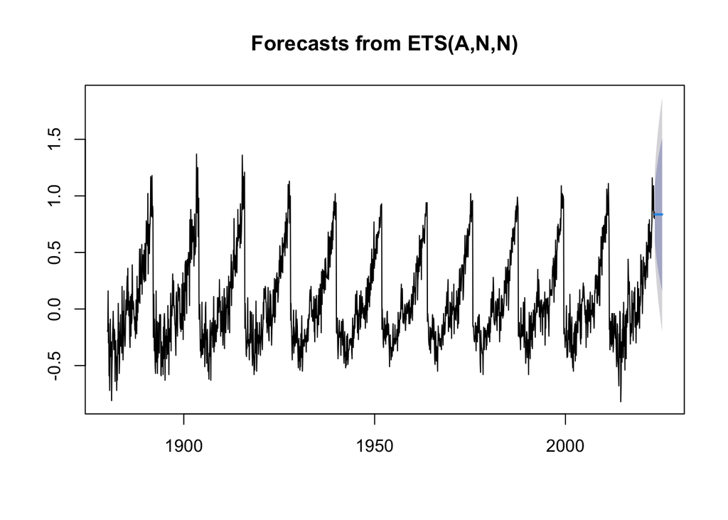

```r
ets_forecast <- forecast(ets_model, h = 24)

ets_forecast <- forecast(ets_model, h = 24)
plot(ets_forecast)
```

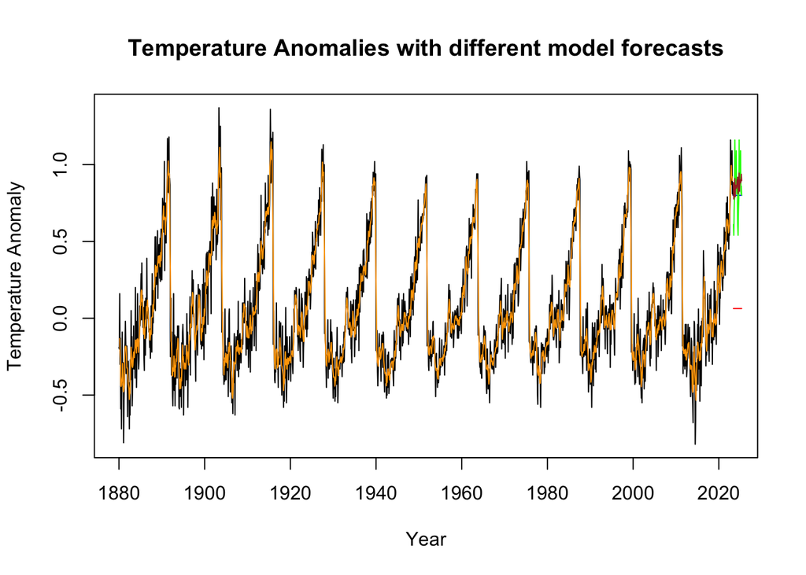

```r
# Plot the original time series
plot(temperature_ts, main = "Temperature Anomalies with different model forecasts", ylab = "Temperature Anomaly", xlab = "Year")

# Add the forecasts to the plot
lines(naive_forecast$mean, col = "blue")
lines(mean_forecast$mean, col = "red")
lines(snaive_forecast$mean, col = "green")
lines(HW_forecast_future$mean, col = "brown")
lines(MA5_forecast, col = "orange")
```

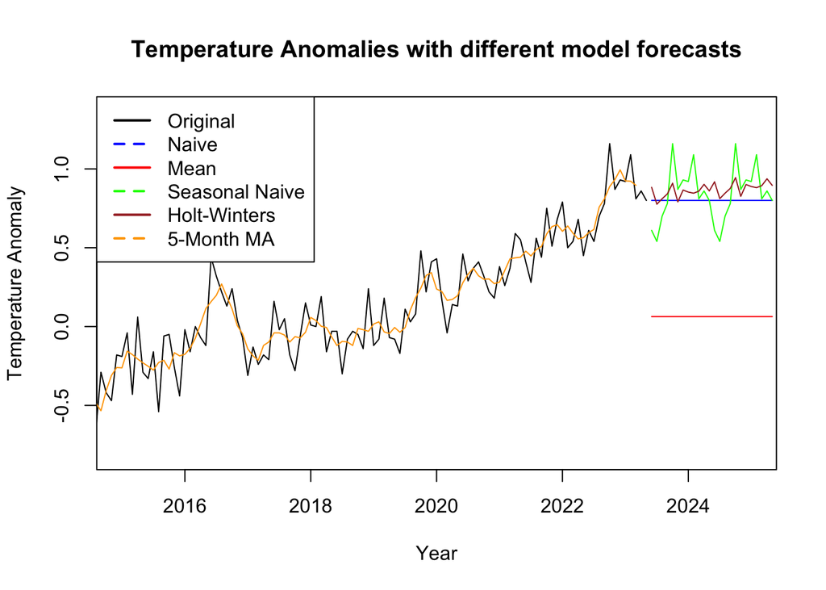

```r
plot(temperature_ts, main = "Temperature Anomalies with different model forecasts", ylab = "Temperature Anomaly", xlab = "Year", xlim = c(2015, 2025))

# Add the forecasts to the plot
lines(naive_forecast$mean, col = "blue")
lines(mean_forecast$mean, col = "red")
lines(snaive_forecast$mean, col = "green")
lines(HW_forecast_future$mean, col = "brown")
lines(MA5_forecast, col = "orange")

legend("topleft", legend = c("Original", "Naive", "Mean", "Seasonal Naive", "Holt-Winters", "5-Month MA"),
       col = c("black", "blue", "red", "green", "brown", "orange"), lty = 1:2, lwd = 2)
```

```r
naive_accuracy <- accuracy(naive_forecast)
mean_accuracy <- accuracy(mean_forecast)
snaive_accuracy <- accuracy(snaive_forecast)
HW_accuracy <- accuracy(HW_forecast_future)
ets_accuracy <- accuracy(ets_forecast)

print(naive_accuracy)
```

```
##                        ME      RMSE     MAE MPE MAPE      MASE       ACF1
## Training set 0.0005755814 0.2075694 0.15275 NaN  Inf 0.5587059 -0.3733667
```

```r
print(mean_accuracy)
```

```
##                        ME      RMSE       MAE  MPE MAPE    MASE      ACF1
## Training set 3.315832e-17 0.3864464 0.3095814 -Inf  Inf 1.13234 0.8546517
```

```r
print(snaive_accuracy)
```

```
##                       ME      RMSE       MAE MPE MAPE MASE    ACF1
## Training set 0.007992978 0.3953733 0.2733996 NaN  Inf    1 0.73462
```

```r
print(HW_accuracy)
```

```
##                        ME      RMSE       MAE MPE MAPE      MASE       ACF1
## Training set -0.005770873 0.1977828 0.1435311 NaN  Inf 0.5249864 0.01717405
```

```r
print(ets_accuracy)
```

```
##                       ME      RMSE       MAE MPE MAPE      MASE         ACF1
## Training set 0.001068163 0.1887038 0.1371498 NaN  Inf 0.5016457 -0.001577603
```

#### RMSE Comparison:

```
•   Naive Model: 0.2076
•   Mean Accuracy Model: 0.3864
•   Seasonal Naïve Model: 0.3954
•   Holt-Winters Model: 0.1978
•   ETS Model: 0.1887
```

####Best Model:

The ETS model has the lowest RMSE of 0.1887, making it the best model based on this accuracy measure. This suggests that the ETS model provides the most accurate forecasts compared to the other models.